# governance-vignette

Olivia Beck

2024-02-19

## How to make a governance index

## Step 0: Identify relevant 990 questions

We first list all questions in the 990 series that we feel indicate governance practices. The questions here have been organized by Part/Schedule of the 990 they are found in.

### Part IV

12a. Whether obtained separate, independent audited financial statements (y/n)

12b. Whether organization included in consolidated, independent audited financial statements (y/n)

28a. Whether the organization a party to a business transaction with a current or former officer, director, trustee, or key employee (y/n)

28b. Whether the organization a party to a business transaction to with a family member of a current or former officer, director, trustee, or key employee (y/n)

28c. Whether the organization a party to a business transaction to with an entity of which a current or former officer, director, trustee, or key employee was an officer, director, trustee, or direct or indirect owner (y/n)

29. Did the organization receive more than 25,000 in non-cash contributions? If yes, complete schedule M. (y/n)
30. Did the organization receive contributions of art, historical treasures, or other similar assets or qualified conservation contributions? If yes, complete schedule M. (y/n)

*Note that if any “yes” to 29 or 30, org is required to indicate whether it has a “gift acceptance policy” in Schedule M, item 31 (y/n)

### Part VI

1a. Number of Voting Members

1b. Number of independent voting members

1.schedule-O. If there are material differences in voting rights among members of the governing body, or if the governing body delegated broad authority to an executive committee or similar committee, explain on Schedule O.

2. Family relationship or business relationship (y/n)
3. Whether used a management company or other person to perform any management duties (y/n)
4. Whether made any significant changes to governing documents (y/n) 5.Whether any significant diversion of assets (y/n)
5. Whether have members or stockholders (y/n)

7a. Whether have any persons who had power to elect or appoint members (y/n) 7b. Whether decisions reserved to members other than governing body (y/n)

8a.Whether documented the meetings by the governing body (y/n) 8b. Whether documented the meetings by each committee (y/n)

10a. Whether have local chapters, branches, or affiliates (y/n) 10b. If yes, whether have a written policies governing the activities for local chapters, branches, or affiliates (y/n)

11a. Whether provided a copy of Form 990 to all members before filing the form (y/n)

12a. Whether have a written conflict of interest policy (y/n) 12b. Whether officers, directors, key employees required to disclose annually interests that could give rise to conflicts? (y/n) 12c. Whether regularly and consistently monitor and enforce compliance with the policy (y/n)

13. Whether have a written whistleblower policy (y/n)
14. Whether have a written document retention and destruction policy (y/n)

15a. Whether have a process for determining compensation of the CEO, executive director, or top management officials include a review and approval by independent persons, comparability data, and deliberation decision (y/n) 15b. Whether have a process for determining compensation of other officers or key employees include a review and approval by independent persons, comparability data, and deliberation decision (y/n)

16a. Whether invest in, contribute assets to, or participate in a joint venture or similar arrangement (y/n) 16b. If yes, whether have a written policy or procedure to evaluate its participation in joint venture or similar arrangements (y/n)

18. Whether make Forms 1023 (or 1024), 990, 990-T available for public inspection in any of the following forms: Own website, another’s website, upon request, other

### Part XII

1. Accounting method used to prepare the Form 990 in any of the following forms: cash, accrual, other

2a. Were the financial statements compiled or reviewed by an independent accountant* (y/n)

2b. Were the financial statements audited by an independent accountant* (y/n)

2c. If yes to 2a or 2b, whether have a committee that assumes responsibility for oversight of the audit, review, or compilation of its financial statements and selection of an independent accountant? (y/n)

3a. Was required to undergo an audit or audits (y/n)

3b. If yes, did undergo the required audit or audits (y/n)

### Schedule M

- Line 31 - “Does the organization have a gift acceptance policy that requires the review of any nonstandard contributions?” - only used if Part IV Line 29 or 30 are checked . yes/no answer.

## Step 1: Get the 990 Data

We read in the raw 990 data from each Part/Schedule for the years we are interested in using as the “base-line” for a governance index. In our case, we use the 2018 returns as our base-line.

```r
#years = 2009:2013
#do 2018
years = 2018
```

### Part IV

```r
### Part IV

#initialize data
dat_4 <-  vector(mode = "list", length = length(years))
#get columns I want
keep_cols_part4 <- c("OBJECTID", "URL", "RETURN_VERSION", "ORG_EIN",
                     "F9_04_AFS_IND_X", "F9_04_AFS_CONSOL_X",
                     "F9_04_BIZ_TRANSAC_DTK_X", "F9_04_BIZ_TRANSAC_DTK_FAM_X", "F9_04_BIZ_TRANSAC_DTK_ENTITY_X",
                     "F9_04_CONTR_NONCSH_MT_25K_X",
                     "F9_04_CONTR_ART_HIST_X")

for(i in 1:length(years)){
  link <-  paste0("https://nccs-efile.s3.us-east-1.amazonaws.com/parsed/F9-P04-T00-REQUIRED-SCHEDULES-", years[i], ".csv")
  temp <- fread(link, select = keep_cols_part4)
  colnames(temp) <- c("OBJECTID", "URL", "RETURN_VERSION", "ORG_EIN",
                     "P4_LINE_12A", "P4_LINE_12B",
                     "P4_LINE_28A", "P4_LINE_28B", "P4_LINE_28C",
                     "P4_LINE_29",
                     "P4_LINE_30")
  dat_4[[i]] <- temp
}

#clean up data
dat_all_4 <-
  rbindlist(dat_4) %>%
  mutate( year = as.numeric(substr(RETURN_VERSION, 1, 4)))
```

### Part VI

```r
### Part VI

#initialize data
dat_6 <-  vector(mode = "list", length = length(years))
#get columns I want
keep_cols_part6 <- c("OBJECTID", "URL", "RETURN_VERSION", "ORG_EIN",
                     "F9_06_INFO_SCHED_O_X",
                     "F9_06_GVRN_NUM_VOTING_MEMB",
                     "F9_06_GVRN_NUM_VOTING_MEMB_IND",
                     "F9_06_GVRN_DTK_FAMBIZ_RELATION_X",
                     "F9_06_GVRN_DELEGATE_MGMT_DUTY_X",
                     "F9_06_GVRN_CHANGE_DOC_X",
                     "F9_06_GVRN_ASSET_DIVERSION_X",
                     "F9_06_GVRN_MEMB_STCKHLDR_X",
                     "F9_06_GVRN_PERS_ELECT_MEMB_X",
                     "F9_06_GVRN_DECISION_APPROV_X",
                     "F9_06_GVRN_DOC_GVRN_BODY_X",
                     "F9_06_GVRN_DOC_COMMITTEE_X",
                     "F9_06_POLICY_CHPTR_AFFIL_X",
                     "F9_06_POLICY_CHPTR_REFERENCE_X",
                     "F9_06_POLICY_FORM990_GVRN_BODY_X",
                     "F9_06_POLICY_COI_X",
                     "F9_06_POLICY_COI_DISCLOSURE_X",
                     "F9_06_POLICY_COI_MONITOR_X",
                     "F9_06_POLICY_WHSTLBLWR_X",
                     "F9_06_POLICY_DOC_RETENTION_X",
                     "F9_06_POLICY_COMP_PROCESS_CEO_X",
                     "F9_06_POLICY_COMP_PROCESS_OTH_X",
                     "F9_06_POLICY_JV_X",
                     "F9_06_POLICY_JV_PROC_X",
                     "F9_06_DISCLOSURE_AVBL_OTH_X",
                     "F9_06_DISCLOSURE_AVBL_OTH_WEB_X",
                     "F9_06_DISCLOSURE_AVBL_REQUEST_X",
                     "F9_06_DISCLOSURE_AVBL_OWN_WEB_X"
                     )

for(i in 1:length(years)){
  link <-  paste0("https://nccs-efile.s3.us-east-1.amazonaws.com/parsed/F9-P06-T00-GOVERNANCE-", years[i], ".csv")
  temp <- fread(link, select = keep_cols_part6)
  colnames(temp) <- c("OBJECTID", "URL", "RETURN_VERSION", "ORG_EIN",
                     "P6_SCHEDULE_O",
                     "P6_LINE_1A",
                     "P6_LINE_1B",
                     "P6_LINE_2",
                     "P6_LINE_3",
                     "P6_LINE_4",
                     "P6_LINE_5",
                     "P6_LINE_6",
                     "P6_LINE_7A",
                     "P6_LINE_7B",
                     "P6_LINE_8A",
                     "P6_LINE_8B",
                     "P6_LINE_10A",
                     "P6_LINE_10B",
                     "P6_LINE_11A",
                     "P6_LINE_12A",
                     "P6_LINE_12B",
                     "P6_LINE_12C",
                     "P6_LINE_13",
                     "P6_LINE_14",
                     "P6_LINE_15A",
                     "P6_LINE_15B",
                     "P6_LINE_16A",
                     "P6_LINE_16B",
                     "P6_LINE_18_other", "P6_LINE_18_other_web", "P6_LINE_18_req", "P6_LINE_18_own_web")
  dat_6[[i]] <- temp
}

#clean up data
dat_all_6 <-
  rbindlist(dat_6) %>%
  mutate( year = as.numeric(substr(RETURN_VERSION, 1, 4)))
```

### Part XII

```r
### Part XII

#initialize data
dat_12 <-  vector(mode = "list", length = length(years))
#Keep all columns for part XII


for(i in 1:length(years)){
  link <-  paste0("https://nccs-efile.s3.us-east-1.amazonaws.com/parsed/F9-P12-T00-FINANCIAL-REPORTING-", years[i], ".csv")
  temp <- fread(link)
  dat_12[[i]] <- temp
}




#clean up data
dat_all_12 <-
  rbindlist(dat_12) %>%
  mutate( year = as.numeric(substr(RETURN_VERSION, 1, 4)))
```

### Schedule M

```r
#initialize data
dat_M <-  vector(mode = "list", length = length(years))
#get columns I want
keep_cols_partM <- c("OBJECTID", "URL", "RETURN_VERSION", "ORG_EIN",
                     "SM_01_REVIEW_PROCESS_UNUSUAL_X")

for(i in 1:length(years)){
  link <-  paste0("https://nccs-efile.s3.us-east-1.amazonaws.com/parsed/SM-P01-T00-NONCASH-CONTRIBUTIONS-", years[i], ".csv")
  temp <- fread(link, select = keep_cols_partM)
  colnames(temp) <- c("OBJECTID", "URL", "RETURN_VERSION", "ORG_EIN",
                     "PM_LINE_31")
  dat_M[[i]] <- temp
}



#clean up data
dat_all_M <-
  rbindlist(dat_M) %>%
  mutate( year = as.numeric(substr(RETURN_VERSION, 1, 4)))
```

## Step 2: Wrangle the 990 Data

We wrangle the 990 data from 0/1, X, t/f, or any other raw coding to a communal “yes/no” response (or other if appropriate) according to the “code book” table in each subsection presented below.

#### Part IV

Line

Variable

Levels

Line 12A, 12B, 28A, 28B, 28C, 29, 30

P4_LINE_12A, …, P4_LINE_30

- “yes” - the answer to this line is yes
- “no” - the answer to this line is no

```r
#remove any unwanted years that may have accidentally appeared
dat_all_4 <-
  dat_all_4 %>%
  filter(year <= max(years))

#standardize yes/no answers
dat_all_4 <-
  dat_all_4 %>%
  mutate(across(starts_with("P4"),
                ~ case_when(
                  . %in% c("true", "1") ~ "yes",
                  . %in% c("false", "0") ~ "no",
                  TRUE ~ .
                )))
```

## Part VI

Line Number

Variable Name

Levels

Line 1A, 1B

P6_LINE_1A, P6_LINE_1B

integer value

Line 2, 3, 4, 5, 6, 7A, 7B, 8A, 8B, 10A, 10B, 11A, 12A, 12B, 12C, 13, 14, 15A, 15B, 16A, 16B

P6_LINE_2, …. , P6_LINE_16B

- “yes” - the answer to this line is yes
- “no” - the answer to this line is no

Line 18

P6_LINE_18

- “own_website” - the own website box on line 18 is checked
- ” others_website” - the another’s website box on line 18 is checked
- “request” - the upon request website box on line 18 is checked
- “other” - the other box on line 18 is checked

Line 1 Schedule O

P6_SCHEDULE_O

- “X” - there is a Schedule O attached to this return with notes from Part VI Line 1
- NA - there is no Schedule O attached to this return with notes from Part VI Line 1

```r
#remove any unwanted years that may have accidentally appeared
dat_all_6 <-
  dat_all_6 %>%
  filter(year <= max(years))

#general wrangling
dat_all_6 <-
  dat_all_6 %>%
  #standardize yes/no answers
  mutate(across(paste0("P6_LINE_", c(2:6, "7A", "7B", "8A", "8B", "10A", "10B", "11A", "12A", "12B", "12C", 13, 14, "15A", "15B", "16A", "16B")) ,
                ~ case_when(
                  . %in% c("true", "1") ~ "yes",
                  . %in% c("false", "0") ~ "no",
                  TRUE ~ .
                )) ) %>%
 # Line 18
  mutate(P6_LINE_18 = case_when(
    P6_LINE_18_own_web == "X" ~ "own_website",
    P6_LINE_18_other_web == "X" ~ "others_website",
    P6_LINE_18_req == "X" ~ "request",
    P6_LINE_18_other == "X" ~ "other"
  )) %>%
  select(-c(P6_LINE_18_own_web,P6_LINE_18_other_web,P6_LINE_18_req, P6_LINE_18_other ))
```

### Part XII

Line Number

Variable Name

Levels

Line 1

P12_LINE_1

- “cash” - cash accounting method
- “accrual” - accrual accounting method
- “other” - other accounting method

Line 1

P12_L I N E _1_OTHER_EXPLAIN

If P12_LINE_1 is “other”, then this is what is written for other

Line 2a

P12_LINE_2A

- “no” - answer to question 2a is no
- “separate” - answer to question 2a is yes and the box for “separate basis” is checked
- “colsol” - answer to question 2a is yes and the box for

“consolidated basis” is checked

- “both” - answer to question 2a is yes and the box for “both consolidated and separate basis” is checked

Line 2b

Notes: Something is wrong about this coding. There are many F 9 _ 1 2 _FINSTAT_AUDIT_X == FALSE, But F9_12_FIN S T A T _AUDIT_CONSOL_X, F9_12_ F I N S TAT_AUDIT_SEP_X, or F9_12_ F I N S TAT_AUDIT_BOTH_X is checked

P12_LINE_2B

- “no” - answer to question 2a is no
- “separate” - answer to question 2b is yes and the box for “separate basis” is checked
- “colsol” - answer to question 2b is yes and the box for

“consolidated basis” is checked

- “both” - answer to question 2b is yes and the box for “both consolidated and separate basis” is checked

Line 2C

P12_LINE_2C

- “no” - answer to question 2c is no
- “yes” - answer to question 2c is no

Line 3A

P12_LINE_3A

- “no” - answer to question 3a is no
- “yes” - answer to question 3a is no

Line 3B

P12_LINE_3B

- “no” - answer to question 3b is no
- “yes” - answer to question 3b is no

```r
#remove any unwanted years that may have accidentally appeared
dat_all_12 <-
  dat_all_12 %>%
  filter(year <= max(years))

## Clean Up Variables
dat_all_12 <-
  dat_all_12 %>%
  ## Line 1
  mutate(P12_LINE_1 = case_when(
    !is.na(F9_12_FINSTAT_METHOD_ACC_OTH) ~ "other",
    F9_12_FINSTAT_METHOD_ACC_ACCRU_X == "X" ~ "accrual",
    F9_12_FINSTAT_METHOD_ACC_CASH_X == "X" ~ "cash"
  )) %>%
  mutate(P12_LINE_1_OTHER_EXPLAIN =
           ifelse(P12_LINE_1 == "other",
                  F9_12_FINSTAT_METHOD_ACC_OTH,
                  NA)) %>%
  ### Line 2a
  mutate(temp_2a = case_when(
    F9_12_FINSTAT_COMPILE_X %in% c("true", "1") ~ "1",
    TRUE ~ "0",
  )) %>%
  mutate(P12_LINE_2A = case_when(
    temp_2a == "0" ~ "no",
    F9_12_FINSTAT_COMPILE_SEP_X == "X" ~ "separate",
    F9_12_FINSTAT_COMPILE_CONSOL_X == "X" ~ "consol",
    F9_12_FINSTAT_COMPILE_BOTH_X == "X" ~ "both"
  )) %>%
  ### Line 2b
  mutate(temp_2b = case_when(
    F9_12_FINSTAT_AUDIT_X %in% c("true", "1") ~ "1",
    TRUE ~ "0",
  ))  %>%
  mutate(P12_LINE_2B = case_when(
    temp_2a == "0" ~ "no",
    F9_12_FINSTAT_AUDIT_SEP_X == "X" ~ "separate",
    F9_12_FINSTAT_AUDIT_CONSOL_X == "X" ~ "consol",
    F9_12_FINSTAT_AUDIT_BOTH_X == "X" ~ "both"
  ))%>%
  ### Line 2c
  mutate(P12_LINE_2C = case_when(
    F9_12_FINSTAT_AUDIT_COMMITTEE_X %in% c("true", "1") ~ "yes",
    TRUE ~ "no",
  ))  %>%
 ### Line 3a
  mutate(P12_LINE_3A = case_when(
    F9_12_FINSTAT_FED_AUDIT_REQ_X %in% c("true", "1") ~ "yes",
    TRUE ~ "no",
  )) %>%
  ### Line 3b
  mutate(P12_LINE_3B = case_when(
    F9_12_FINSTAT_FED_AUDIT_PERF_X %in% c("true", "1") ~ "yes",
    TRUE ~ "no",
  ))  %>%
  #only keeping relevant variables
  select(OBJECTID,URL, RETURN_VERSION,ORG_EIN,RETURN_TYPE,TAX_YEAR,
         P12_LINE_1,P12_LINE_1_OTHER_EXPLAIN,
         P12_LINE_2A, P12_LINE_2B, P12_LINE_2C,
         P12_LINE_3A, P12_LINE_3B) %>%
  ### rename year to be consistent with other data.frames
  rename(year = TAX_YEAR)
```

### Schedule M

Line

Variable

Levels

Line 31

PM_LINE_31

- “yes” - the answer to this line is yes
- “no” - the answer to this line is no

```r
#remove any unwanted years that may have accidentally appeared
dat_all_M <-
  dat_all_M %>%
  filter(year <= max(years))

#standardize yes/no answers
dat_all_M <-
  dat_all_M %>%
  mutate(PM_LINE_31 = case_when(
                  PM_LINE_31 %in% c("true", "1") ~ "yes",
                  PM_LINE_31 %in% c("false", "0") ~ "no",
                  TRUE ~ NA
                ))
```

### Merge all parts into one data set

In this subsection, we also remove all EZ filers since most of them will not have complete data in the item responses we are considering, and we need complete responses to do a factor analysis.

```r
#merge
#filter out all EZ's
dat_govern <-
  dat_all_4 %>%
  merge(dat_all_6, by = c("OBJECTID", "URL", "RETURN_VERSION", "ORG_EIN", "year")) %>%
  merge(dat_all_12, by = c("OBJECTID", "URL", "RETURN_VERSION", "ORG_EIN", "year")) %>%
  merge(dat_all_M, by = c("OBJECTID", "URL", "RETURN_VERSION", "ORG_EIN", "year")) %>%
  filter(RETURN_TYPE != "990EZ")
```

INTERNAL PACKAGE NOTE: At this point, `dat_govern` is what is in the `metadata-standards/governance/governance.Rdata` file.

## Step 3: Transform 990 Data into features matrix

The first thing we have to do in order to make a features matrix is assign all of our yes/no values to 1 for what we believe are positive governance practices or 0 for what we believe are negative governance practices. i.e.

- 1 is positive direction (i.e. good governance practices)
- 0 is negative direction (i.e. bad governance practices)

| Variable Name(s) | Original Coding | Design Matrix Coding |
| --- | --- | --- |
| P4_LINE_12A P4_LINE_12B | yes/no yes/no | 1 - yes to either 12A or 12B 0 - no to both |
| P4_Line_28A, B, C | yes/no yes/no yes/no | 0 - no to all 1 - yes to any of 28A, 28B, or 28C |
| P4_Line_29 P4_Line_30 PM_LINE_31 | yes/no yes/no yes/no/na | 1 - (29 no) or (30 no) or (29 yes and PM 31 yes) or (30 yes and PM 31 yes) 0 - (29 yes and PM 31 no) or (30 yes and PM 31 no) |
| P6_LINE_1A, P6_LINE_1B | numeric | is P6_LINE_1B / P6_LINE_1A >= 0.5 \| i.e. is the proportion of independent members at least 0.5? \| |
| P6_LINE_2 | yes/no | 0/1 (no is good) |
| P6_LINE_3 | yes/no | 0/1 (no is good) |
| P6_LINE_4 | yes/no | removed, neither yes or no is not good nor bad |
| P6_Line_5 | yes/no | 0/1 (no is good) |
| P6_Line_6 | yes/no | removed. neither is good or bad. only answers to P6_Line_7A/B matter |
| P6_LINE_7A | yes/no | 0/1 (no is good) |
| P6_Line_7B | yes/no | 0/1 (no is good) |
| P6_LINE_10A P6_LINE_10B | yes/no yes/no/NA | 1 - (10A no) or (10A yes + 10B yes) 0 - (10A yes + 10B no) |
| P6_LINE_12B | yes/no/NA | 1 - (12A yes + 12B yes) or (12A no) 0 - (12 A yes + 12B no) |
| P6_LINE_12C | yes/no/NA | 1 - (12A yes + 12C yes) or (12A no) 0 - (12 A yes + 12C no) |
| P6_LINE_16A P6_LINE_16B | yes/no yes/no/NA | 1 - (16A no) or (16A yes + 16B yes) 0 - (16A yes + 16B no) |
| P6_LINE_18 | request/own we bsite/another’s website/other | 1 - own website 0 - anything else |
| All other P6_* | yes/no | 1/0 |
| P12_LINE_1 | Accrual/cash | 1 - Accrual 0 - anything else |
| P12_LINE_2A | both/c on sol/no/seperate | 0 - no 1 - anything else |
| P12_LINE_2B | both/c on sol/no/seperate | 0 - no 1 - anything else |
| P12_LINE_2C | yes/no/NA | 1 -( 2B yes + 2C yes ) or (2A yes + 2C yes) or (2a no ) or (2b no) 0- (2a yes and 2c no) or (2b yes and 2c no) |
| P12_LINE_3A/ P12_LINE_3B | yes/no yes/no | 1 - (3a no) + (3a yes +3b yes) 0 - (3a yes + 3b no) |

```r
#For P6_LINE_1B / P6_LINE_1A >= 0.625
indep_members_threshold <- 0.5 #this is ~ the median value for this data set


design_mat <-
  dat_govern %>%
  #dont need P6_SCHEDULE_O, P12_LINE_1_OTHER_EXPLAIN, RETURN TYPE
  select(- c(P6_SCHEDULE_O, P12_LINE_1_OTHER_EXPLAIN, RETURN_TYPE, P6_LINE_4)) %>%
  #remove all is.na in all columns except P6_LINE_10B, P6_LINE_12B, P6_LINE_12C, P6_LINE_16B, PM_LINE_31
  filter(if_all(-c(P6_LINE_10B, P6_LINE_12B, P6_LINE_12C, P6_LINE_16B, P6_LINE_18, PM_LINE_31),
                ~ !is.na(.))) %>%
  #P4 Line 12
  mutate(P4_LINE_12 = ifelse(P4_LINE_12A == "yes" | P4_LINE_12B == "yes", 1, 0)) %>%
  select(-c(P4_LINE_12A, P4_LINE_12B))%>%
  #P4 line 28
  mutate(P4_LINE_28 = ifelse(
    P4_LINE_28A == "yes" |
      P4_LINE_28B == "yes" |
      P4_LINE_28C == "yes" , 0, 1)) %>%
  select(-c(P4_LINE_28A, P4_LINE_28B, P4_LINE_28C)) %>%
  #P4 line 29 and 30, Schedule M
  mutate(P4_LINE_29_30 = case_when(
    P4_LINE_29 == "yes" & PM_LINE_31 == "no" ~ 0,
    P4_LINE_30 == "yes" & PM_LINE_31 == "no" ~ 0,
    TRUE ~ 1)) %>%
  select(-c(P4_LINE_29, P4_LINE_30, PM_LINE_31)) %>%
  #P6_LINE_1
  filter(P6_LINE_1A != 0) %>% # remove divide by 0 errors
  filter(P6_LINE_1A > P6_LINE_1B) %>% # only keep cases where we have more members than independent members
  mutate(P6_LINE_1 = ifelse(P6_LINE_1B / P6_LINE_1A >= indep_members_threshold, 1, 0)) %>%
  select(-c(P6_LINE_1B , P6_LINE_1A )) %>%
  #P6_LINE_2, 3, 5, 7A, 7B all have no as good and yes as bad
  mutate_at(vars("P6_LINE_2", "P6_LINE_3", "P6_LINE_5", "P6_LINE_7A", "P6_LINE_7B") ,
            ~ ifelse(. == "no", 1, 0)) %>%
  #P6_Line_10
  mutate(P6_LINE_10 = case_when(
    P6_LINE_10A == "no"  ~ 1,
    P6_LINE_10A == "yes" & P6_LINE_10B == "yes" ~ 1,
    P6_LINE_10A == "yes" & P6_LINE_10B == "no"  ~ 0
  )) %>%
  select(-c(P6_LINE_10A, P6_LINE_10B)) %>%
  #P6_LINE_12B
  mutate(P6_LINE_12B = case_when(
    P6_LINE_12A == "no"  ~ 1,
    P6_LINE_12A == "yes" & P6_LINE_12B == "yes" ~ 1,
    P6_LINE_12A == "yes" & P6_LINE_12B == "no"  ~ 0
  )) %>%
  #P6_LINE_12C
  mutate(P6_LINE_12C = case_when(
    P6_LINE_12A == "no"  ~ 1,
    P6_LINE_12A == "yes" & P6_LINE_12C == "yes" ~ 1,
    P6_LINE_12A == "yes" & P6_LINE_12C == "no"  ~ 0
  )) %>%
  #P6_LINE_16
  mutate(P6_LINE_16 = case_when(
    P6_LINE_16A == "no"  ~ 1,
    P6_LINE_16A == "yes" & P6_LINE_16B == "yes" ~ 1,
    P6_LINE_16A == "yes" & P6_LINE_16B == "no"  ~ 0
  )) %>%
  select(-c(P6_LINE_16A, P6_LINE_16B)) %>%
  # P6_LINE_18
  mutate(P6_LINE_18 = case_when(
    P6_LINE_18 == "own_website" ~ 1 ,
    is.na(P6_LINE_18) ~ 0,
    TRUE ~ 0
  )) %>%
  # All other P6 yes is good, no is bad
  mutate_at(vars( paste0("P6_LINE_", c("8A", "8B", "11A", "12A", 13, 14, "15A", "15B"))),
            ~  ifelse(. == "yes", 1, 0)) %>%
  # P12_LINE_1
  mutate(P12_LINE_1 = ifelse(P12_LINE_1 == "accrual", 1, 0)) %>%
  # P12_Line_2A
  mutate(P12_LINE_2A = ifelse(P12_LINE_2A == "no", 0, 1)) %>%
  # P12_Line_2B
  mutate(P12_LINE_2B = ifelse(P12_LINE_2B == "no", 0, 1)) %>%
  #P12_Line_2C
  mutate(P12_LINE_2C = case_when(
    P12_LINE_2A == "no" ~ 1,
    P12_LINE_2B == "no" ~ 1,
    P12_LINE_2A == "yes" & P12_LINE_2C == "yes" ~ 1,
    P12_LINE_2B == "yes" & P12_LINE_2C == "yes" ~ 1,
    P12_LINE_2A == "yes" & P12_LINE_2C == "no" ~ 0,
    P12_LINE_2B == "yes" & P12_LINE_2C == "no" ~ 0,
    TRUE ~ 0
  )) %>%
  #P12_Line_3
  mutate(P12_LINE_3 = case_when(
    P12_LINE_3A == "no" ~ 1,
    P12_LINE_3A == "yes" & P12_LINE_3B == "yes" ~ 1,
    P12_LINE_3A == "yes" & P12_LINE_3B == "no" ~ 0,
    TRUE ~ 0
  )) %>%
  select(-c(P12_LINE_3A, P12_LINE_3B))


#Remove P6_Line_6
design_mat <-
  design_mat %>%
  select(-P6_LINE_6)

# nothing is NA
dim(design_mat)
```

```
## [1] 64139    32
```

```r
dim(na.omit(design_mat))
```

```
## [1] 64113    32
```

```r
#store ID's to remove from data set for analysis
design_mat_ID <- design_mat[, 1:5]
design_mat <- design_mat[, -(1:5)]
```

## Step 4: Exploring correlation structures

Throughout this section we use the polychoric correlations and not the Pearson correlations. This is because all of our features are binary, and polychoric correlations are specifically designed for ordinal variables. See [here](https://stats.oarc.ucla.edu/stata/faq/how-can-i-perform-a-factor-analysis-with-categorical-or-categorical-and-continuous-variables/) for more details on use of polychoric correlations in factor analysis.

### Basic EDA

We first start with some basic exploratory data analysis to see the general structure of our data.

```r
tab_list <- design_mat %>%
  map( function(x) as.data.frame(table(x) ))

tab_summary <-
  rbindlist(tab_list,
          idcol = TRUE,
          fill = TRUE) %>%
  as.data.frame() %>%
  mutate(x = paste0("num", x)) %>%
  pivot_wider(names_from = "x", values_from = "Freq") %>%
  mutate(perc0 = round(num0 / (num0 + num1), 3),
         perc1 = round(num1 / (num0 + num1), 3))%>%
  arrange(.id)

tab_summary%>%
  kable() %>%
  kable_styling()
```

| .id | num0 | num1 | perc0 | perc1 |
| --- | --- | --- | --- | --- |
| P12_LINE_1 | 22986 | 41153 | 0.358 | 0.642 |
| P12_LINE_2A | 63197 | 942 | 0.985 | 0.015 |
| P12_LINE_2B | 63197 | 942 | 0.985 | 0.015 |
| P12_LINE_2C | 64139 | NA | NA | NA |
| P12_LINE_3 | 48 | 64091 | 0.001 | 0.999 |
| P4_LINE_12 | 33827 | 30312 | 0.527 | 0.473 |
| P4_LINE_28 | 7042 | 57097 | 0.110 | 0.890 |
| P4_LINE_29_30 | 3821 | 60318 | 0.060 | 0.940 |
| P6_LINE_1 | 26981 | 37158 | 0.421 | 0.579 |
| P6_LINE_10 | 102 | 64037 | 0.002 | 0.998 |
| P6_LINE_11A | 20598 | 43541 | 0.321 | 0.679 |
| P6_LINE_12A | 24219 | 39920 | 0.378 | 0.622 |
| P6_LINE_12B | 2908 | 61212 | 0.045 | 0.955 |
| P6_LINE_12C | 4647 | 59491 | 0.072 | 0.928 |
| P6_LINE_13 | 33593 | 30546 | 0.524 | 0.476 |
| P6_LINE_14 | 31457 | 32682 | 0.490 | 0.510 |
| P6_LINE_15A | 38303 | 25836 | 0.597 | 0.403 |
| P6_LINE_15B | 44295 | 19844 | 0.691 | 0.309 |
| P6_LINE_16 | 301 | 63832 | 0.005 | 0.995 |
| P6_LINE_18 | 59977 | 4162 | 0.935 | 0.065 |
| P6_LINE_2 | 13764 | 50375 | 0.215 | 0.785 |
| P6_LINE_3 | 3820 | 60319 | 0.060 | 0.940 |
| P6_LINE_5 | 63 | 64076 | 0.001 | 0.999 |
| P6_LINE_7A | 17610 | 46529 | 0.275 | 0.725 |
| P6_LINE_7B | 12013 | 52126 | 0.187 | 0.813 |
| P6_LINE_8A | 7530 | 56609 | 0.117 | 0.883 |
| P6_LINE_8B | 14324 | 49815 | 0.223 | 0.777 |

We can see from this table that there are quite a few features that have either all 0’s, all 1’s, or a very small percentage of 0’s and 1’s. Additionally, there are a few factors that are perfectly correlated with other factors (e.g. P12_LINE_2B and P12_LINE_2A are perfectly correlated) These features probably will not be helpful in our analysis since they do not contain enough variation to tell us anything useful. Let’s remove these factors from our analysis.

```r
### Remove factors where less than 2% in either class
### This was as small as we could make it in this data set without the correlation matrix being singular
### Remove P12_Line_2B because it is perfectly correlated with 2A
### Remove P6_Line_12B, P6_Line_12C because it is causing singularity issues with P6_Line_12
perc_threshold <- 0.02

#list of variables to keep
vars_keep <-
  tab_summary %>%
  filter(perc0 > perc_threshold & perc1 > perc_threshold) %>%
  filter(.id != "P12_LINE_2B") %>%
  filter(.id != "P6_LINE_12B") %>%
  filter(.id != "P6_LINE_12C") %>%
  pull(.id) %>%
  sort()
```

Next we look at the general correlation structure. We can see from the plot below that there are several variables that are extremely correlated with each other (>90%). Let’s explore some of these more.

```r
# make as factor
design_mat_keep <- sapply(design_mat[, ..vars_keep], as.factor) #note the ..vars_keep. the ".." is deliberalty needed in datatable package updates

#hecor computes polychoric correlations between ordinal variables.
corr_mat <- hetcor(design_mat_keep, ML = TRUE) #uses maximum likelihood estimates
```

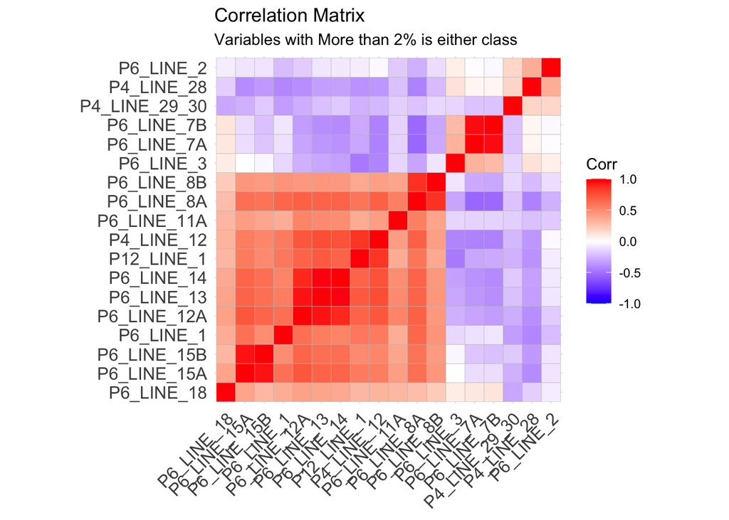

```r
ggcorrplot(corr_mat$correlations,
           hc.order = TRUE ) +
  ggtitle("Correlation Matrix") +
  labs(subtitle = "Variables with More than 2% is either class")
```

### Exploring Highly Correlated Variables

```r
dat_cor <- as.data.frame(corr_mat$correlations)
dat_cor$var1 <- rownames(dat_cor)

dat_cor%>%
  pivot_longer(!var1, names_to = "var2", values_to = "cor") %>%
  filter(var1 != var2) %>%
  arrange(desc(abs(cor))) %>%
  filter(abs(cor) >= 0.90)
```

```
## # A tibble: 8 × 3
##   var1        var2          cor
##   <chr>       <chr>       <dbl>
## 1 P6_LINE_13  P6_LINE_14  0.958
## 2 P6_LINE_14  P6_LINE_13  0.958
## 3 P6_LINE_7A  P6_LINE_7B  0.949
## 4 P6_LINE_7B  P6_LINE_7A  0.949
## 5 P6_LINE_15A P6_LINE_15B 0.939
## 6 P6_LINE_15B P6_LINE_15A 0.939
## 7 P6_LINE_12A P6_LINE_13  0.936
## 8 P6_LINE_13  P6_LINE_12A 0.936
```

#### P6_LINE_12A, 13, 14

First, look at correlations of P6_line 12A, 13, 14. They are quite strong so let’s make a new variable. P6_Line_12_13_14 = 1 if (P6_Line_13 ==a yes AND P6_Line_14 == yes AND P6_Line_12A == yes) and 0 otherwise. These all get a a similar sentiment: do you have documented policies?

```r
## All 3 are very correlated
design_mat %>%
  select(P6_LINE_13, P6_LINE_14, P6_LINE_12A) %>%
  mutate_all(as.factor) %>%
  hetcor(ML = TRUE)
```

```
##
## Maximum-Likelihood Estimates
##
## Correlations/Type of Correlation:
##             P6_LINE_13 P6_LINE_14 P6_LINE_12A
## P6_LINE_13           1 Polychoric  Polychoric
## P6_LINE_14      0.9579          1  Polychoric
## P6_LINE_12A     0.9362     0.8932           1
##
## Standard Errors:
##             P6_LINE_13 P6_LINE_14
## P6_LINE_13
## P6_LINE_14    0.001039
## P6_LINE_12A   0.001544   0.002071
##
## n = 64139
```

```r
## Even combing 13 and 14 is still very correlated
design_mat %>%
  select(P6_LINE_13, P6_LINE_14, P6_LINE_12A) %>%
  mutate(P6_LINE_13_14 = P6_LINE_13 == 1 & P6_LINE_14 == 1) %>%
  select(-c(P6_LINE_13, P6_LINE_14)) %>%
  mutate_all(as.factor) %>%
  hetcor(ML = TRUE)
```

```
##
## Maximum-Likelihood Estimates
##
## Correlations/Type of Correlation:
##               P6_LINE_12A P6_LINE_13_14
## P6_LINE_12A             1    Polychoric
## P6_LINE_13_14      0.9305             1
##
## Standard Errors:
## [1] ""        "0.00171"
##
## n = 64139
```

```r
design_mat <- design_mat %>%
  mutate(P6_LINE_12_13_14 = as.numeric(
    P6_LINE_12A == 1 & P6_LINE_13 == 1 & P6_LINE_14 == 1)) %>%
  select(-c(P6_LINE_12A, P6_LINE_13, P6_LINE_14))
```

With this, we conclude we should just combine all of P6_LINE_12A, 13, and 14 into one factor.

#### P6_LINE_7A, 7B

- P6_LINE_6 = Did the organization have members or stockholders?
- P6_Line_7A = Did the organization have members, stockholders, or other persons who had the power to elect one or more members of the governing body?
- P6_Line_7B = Are any governance decisions of the organization reserved to (or subject to approval by) members, stockholders, or persons other than the governing body?

```r
design_mat %>%
  select(P6_LINE_7A, P6_LINE_7B) %>%
  mutate_all(as.factor) %>%
  hetcor(ML = TRUE)
```

[output not shown]

```r
design_mat <-
  design_mat %>%
  mutate(P6_LINE_7 = as.numeric(P6_LINE_7A == 1 & P6_LINE_7B == 1)) %>%
  select(!c(P6_LINE_7B, P6_LINE_7A))
```

Ultimately, we choose to remove P6_Line_7 all together because we did not feel addressing questions regarding stakeholders was helpful in the type of governance we wanted to measure. This was our opinion on governance practices we were interested in, other researchers may feel differently. P6_LINE_7 mathematically can be included in the factor analysis as it is not highly correlated with any of the other factors

#### P6_LINE_15A, 15B

For this one, let’s just keep P6_Line_15A. It get’s at the main point that we care about. And most people aren’t doing one or the other; most people do both or neither.

- P6_LINE_15A = compensation review and approval for CEO?
- P6_LINE_15B = compensation review and approval for other officers and key employees?

```r
design_mat %>%
  select(P6_LINE_15A, P6_LINE_15B) %>%
  mutate(P6_LINE_15A = as.factor(P6_LINE_15A),
         P6_LINE_15B = as.factor(P6_LINE_15B)) %>%
  hetcor(ML = TRUE)
```

```
##
## Maximum-Likelihood Estimates
##
## Correlations/Type of Correlation:
##             P6_LINE_15A P6_LINE_15B
## P6_LINE_15A           1  Polychoric
## P6_LINE_15B      0.9388           1
##
## Standard Errors:
## [1] ""        "0.00146"
##
## n = 64139
```

```r
design_mat <-
  design_mat %>%
  select(-P6_LINE_15B)
```

#### P6_LINE_8B

We may also want to remove P6_Line_8B. It is causing non-positive-definite issues and is very highly correlated with 8A. Similar to above, both items tell a similar sentiment.

8a.Whether documented the meetings by the governing body (y/n) 8b. Whether documented the meetings by each committee (y/n)

```r
design_mat %>%
  select(P6_LINE_8A, P6_LINE_8B) %>%
  mutate(P6_LINE_8A = as.factor(P6_LINE_8A),
         P6_LINE_8B = as.factor(P6_LINE_8B)) %>%
  hetcor(ML = TRUE)
```

[output not shown]

```r
design_mat <-
  design_mat %>%
  select(-P6_LINE_8B)
```

### Looking at the correlations again

Let’s look at our new correlation structure.

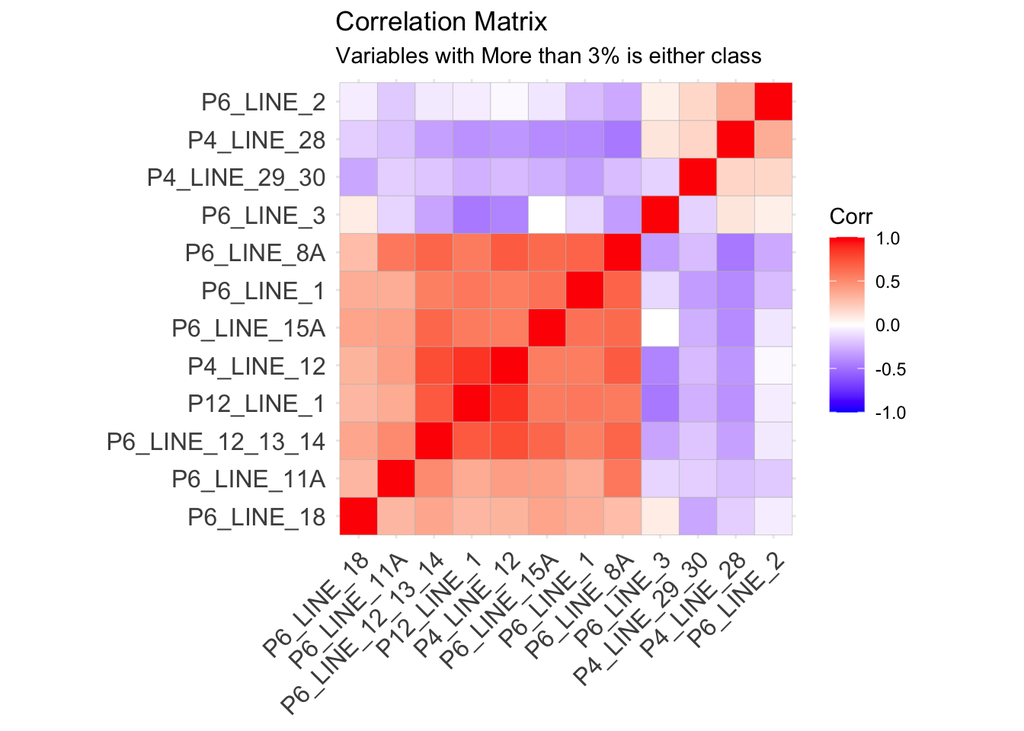

```r
#### Trying the Correlations Again without the problematic variables

#updated the variables to keep
#add the variables I added
adding <- c("P6_LINE_12_13_14")
vars_keep2 <- c(vars_keep, adding)
 #remove the variables I removed
removing <- c("P6_LINE_7A", "P6_LINE_7B",
              "P6_LINE_13", "P6_LINE_14", "P6_LINE_12", "P6_LINE_12A",
              "P6_LINE_15B",
              "P6_LINE_8B",
              "P6_LINE_7")

vars_keep2 <- vars_keep2[!(vars_keep2 %in% removing)]

design_mat2 <- sapply(design_mat[, ..vars_keep2], as.factor) #note the ..vars_keep. the ".." is deliberalty needed in datatable package updates


corr_mat2 <- hetcor(design_mat2, ML = TRUE)

ggcorrplot(corr_mat2$correlations,
           hc.order = TRUE ) +
  ggtitle("Correlation Matrix") +
  labs(subtitle = "Variables with More than 3% is either class")
```

This looks like a much more reasonable correlation structure to work with!

## Step 5: Pick final fetures to go into factor analysis

We choose to use P12_LINE_1, P4_LINE_12, P4_LINE_28, P4_Line_29_30, P6_Line_1, P6_Line_2, P6_Line_3, P6_Line_8A, P6_Line_11A, P6_Line_12_13_14, P6_Line_15A, and P6_Line_18 as our factors for the analysis.

### Summary of Variables Used in Index

All variables are coded as 1 (good governance practice) or 0 (bad governance practice)

| Vari able Name | Variable Meaning/Coding |  |
| --- | --- | --- |
| P4_ LINE _12A | Did the org obtain separate, independent audited financial statements? 1 - yes, 0 - no |  |
| P4 _LIN E_28 | 1- Answered “no” to questions P4_LINE_28A, P4_LINE_28B, **AND** P4_LINE_28 0 - Answered yes to any of these questions Essentially 1 if no business was done with a family member and 0 otherwise. |  |
| P 4_LI NE_2 9_30 | 1- (Answered no to P4_LINE_29 ANDP4_Line_29) or (Answered yes to (P4_LINE_29 ORP4_Line_29) AND answered yes to Schedule M question 31 ) 0 - Answered yes to (P4_LINE_29 ORP4_Line_29) AND answered no to… |  |
| P 6_LI NE_1 | 1 - The proportion of independent members on the board is at least 50% 0 - The proportion of independent members on the board is less than 50% |  |
| P 6_LI NE_2 | 1- **No** officer, director, trustee, or key employee had a family relationship or a business relationship with any other officer, director, trustee, or key employee 0- **An** officer, director, trust… |  |
| P 6_LI NE_3 | 1- The org **did not** use a management company or other person to perform any management duties 0 - The org **did** use a management company or other person to perform any management duties |  |
| P6 _LIN E_8A | 1 - The meetings by the governing body **are** documented 0 - The meetings by the governing body **are** **not** documented |  |
| P6_L INE_ 12_1 3_14 | 1- The answers to P6_Line_12, 13, and 14 are all yes 0- otherwise i.e. 1 if the organization has a written conflict of interest policy, **AND** a written whistleblower policy, **AND** a written retent… |  |
| P6_ LINE _11A | 1- A copy of Form 990 is provided to all members before filing the form 0 - otherwise |  |
| P6_ LINE _15A | 1- The org has a process for determining compensation of the CEO, executive director, or top management officials including a review and approval by independent persons, comparability data, and delibe… |  |
| P6 _LIN E_18 | 1 - Forms 1023 (or 1024), 990, 990-T available for public inspection on own website 0 - These forms were listed on another’s website, available upon request, or “other” |  |
| P1 2_LI NE_1 | Did the org use accrual method for accounting? 1 - yes, 0- no |  |

### Summary of Variables Not Used in Index

| Variable Name | Reason why it is not used |
| --- | --- |
| P4_LINE_12B | Perfectly correlated with P4_Line_12A |
| P6_LINE_4 | Removed, neither good nor bad |
| P6_Line_5 | Less than 3% in 0 category |
| P6_Line_6 | Removed, neither good nor bad |
| P6_LINE_7A, P6_LINE_7B | Causing singularity issues |
| P6_Line_8B | Perfectly correlated with P6_Line_8A |
| P6_Line_12B, P6_LINE_12C | Folded into question 12A, |
| P6_LINE_15A | Perfectly correlated with P6_Line_15A |
| P6_LINE_16A, P6_LINE_16B | Less than 3% in 0 category |
| P12_LINE_2A, P12_LINE_2C | Less than 3% in 1 category |
| P12_LINE_2B | Perfectly correlated with P12_Line_2A |

```r
#make the features matrix
features2 <-  matrix(
  as.numeric(design_mat2), ncol = ncol(design_mat2))

colnames(features2) <- colnames(design_mat2)

## Polychoric correlation
poly_cor2 = psych::polychoric(features2)
rho2 = poly_cor2$rho
```

## Step 6: Run the Factor Analysis

Note: We choose to use the “equamax” rotation in our factor analysis. See https://www.ibm.com/docs/en/spss-statistics/25.0.0?topic=analysis-factor-rotation for details. We want independent factors, and equamax balances simplifying the factors (from varimax) and simplifying the variables (quartimax).

#### Pick the number of factors

Before we can run a factor analysis, we have to pick the number of factors we want to look at. To do that we look at the scree plot.

We choose to use 6 factors based on the plot below and after testing the interpretability of our results at variout number of factors.

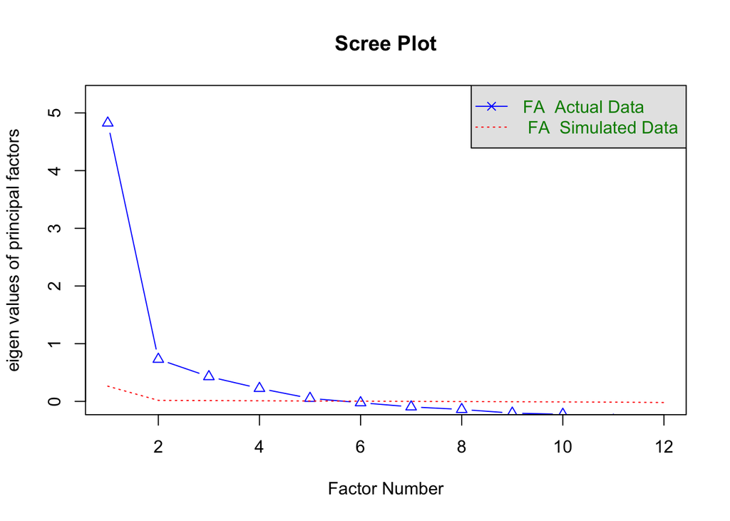

```
## Parallel analysis suggests that the number of factors =  5  and the number of components =  NA
```

```r
fa.parallel(rho2,
            fm="pa",
            fa="fa",
            main = "Scree Plot",
            cor = "poly",
            nfactors = 1,
            n.obs = nrow(design_mat_keep))
```

### Run the factor analysis:

Once we have decided we will use 6 factors, we run the factor analysis model.

```r
set.seed(98435)
model2.6 = fa(features2, nfactor=6, cor="poly", fm="mle", rotate = "equamax")
model2.6$loadings
```

```
##
## Loadings:
##                  ML1    ML2    ML4    ML3    ML6    ML5
## P12_LINE_1        0.654  0.103  0.422  0.372  0.221  0.274
## P4_LINE_12        0.825  0.346  0.244  0.259  0.241
## P4_LINE_28       -0.170 -0.294 -0.244               -0.425
## P4_LINE_29_30    -0.204        -0.117  0.214 -0.164 -0.413
## P6_LINE_1         0.280  0.401  0.424         0.167  0.421
## P6_LINE_11A       0.111  0.362  0.130         0.605
## P6_LINE_15A       0.248  0.346  0.729         0.260  0.150
## P6_LINE_18        0.203         0.243 -0.150  0.397  0.185
## P6_LINE_2         0.163 -0.226                      -0.509
## P6_LINE_3        -0.181 -0.115        -0.920
## P6_LINE_8A        0.246  0.816  0.281  0.213  0.296  0.236
## P6_LINE_12_13_14  0.466  0.289  0.445  0.204  0.439
##
##                  ML1   ML2   ML4   ML3   ML6   ML5
## SS loadings    1.711 1.446 1.379 1.230 1.043 0.998
## Proportion Var 0.143 0.121 0.115 0.102 0.087 0.083
## Cumulative Var 0.143 0.263 0.378 0.480 0.567 0.651
```

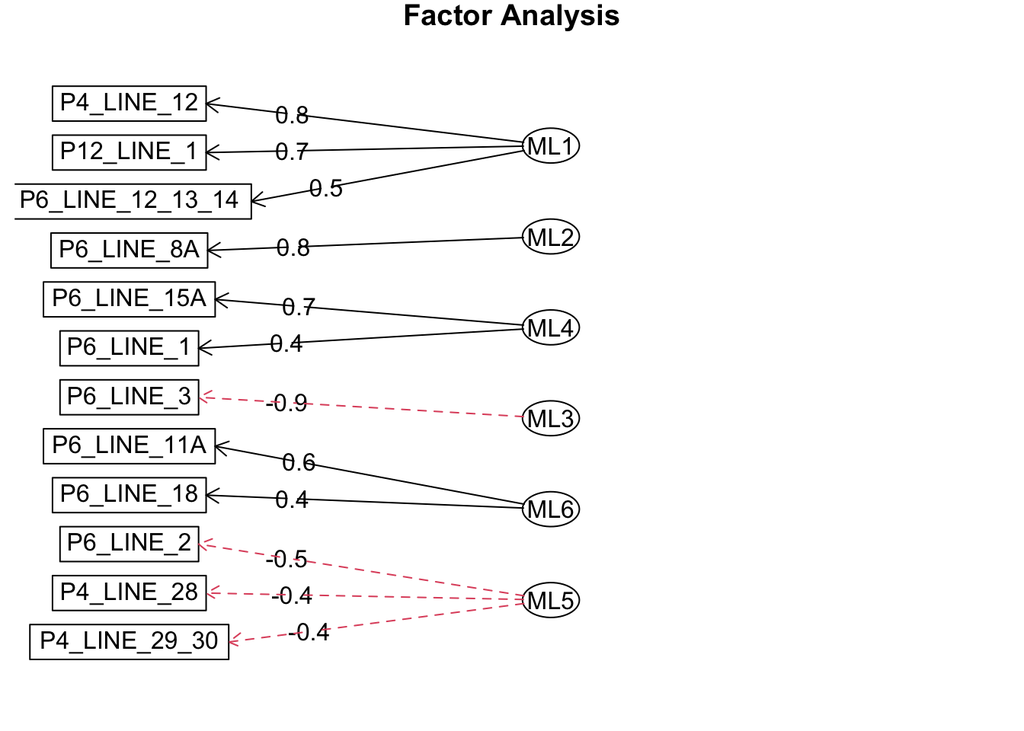

```r
fa.diagram(model2.6)
```

Cumulatively, we explain ~65% of the variance in our data set, which is a value we are comfortable with.

INTERNAL PACKAGE NOTE, Step 6 is essentially what the `metadata-standards/governance/pkg-funcs/storing-factors-objects.R` file is doing. After this step, the necessary objects needed to do the factor analysis and calculate new scores are found in the `metadata-standards/governance/pkg-funcs/factor-objects.Rdata` file.

### Adding Factor Scores

The original `fa` function will calculate factor scores, but they are not the factor scores we are interested in. Instead, we use the `factor.scores` function to specify the exact method we wish to use when calculating our factor scores.

- We need to specify the exact correlation (polychoric) structure we are using to calculate our factor scores. (The `fa` function will default to using the Pearson correlations in the score calculations even if you explicitly tell it to use the polychoric ones when finding the factors).
- We need to specify “Thurstone” method to use the “regression based weights” when calculating the scores.
- For each organization, we first find the score loaded onto each factor, then use the sum of those 6 factor scores as the total score.

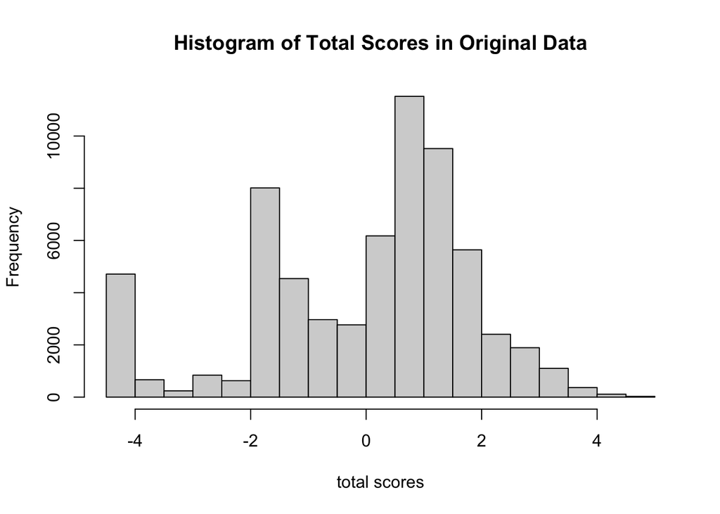

```r
scores <- factor.scores(features2,
                        model2.6,
                        rho = polychoric(features2)$rho,
                        method = "Thurstone")


all.dat <- cbind(features2, scores$scores)
all.dat <- as.data.frame(all.dat)

all.dat$total.score <- rowSums(scores$scores)
hist(all.dat$total.score,
     main = "Histogram of Total Scores in Original Data",
     xlab = "total scores")
```

## Step 7: Interpret the Factors

#### 6 Factors:

Variables( positive meaning i.e. value = 1)

Factor Group Names

- P12_Line_1: Accounting method is accural (bad is anything else)
- P4_Line_12: The organization obtains separate, independent audited financial statements
- P6_Line_12_13_14: The organization has a written conflict of interest policy, a written whistleblower policy, and a written retention and destruction policy
- Have doc

written

accounting

practices and

general

policies

- P6_LINE_8A: The meetings by the governing body are documented
  - Correlated with 8b. meetings by each committee are documented
- Open d

nizational

business

- P6_LINE_15A: The org has a process for determining compensation of the CEO, executive director, or top management officials including a review and approval by independent persons, comparability data, and deliberation decision
  - Correlated with Line 15b. The org has a process for determining compensation of other officers or key employees includin a review and approval by independent persons, comparability data, and deliberation decision
- P6_Line_1: The percent of independent members on the voting board is >50%
- Good

policies for making the board and for paying them

- (Negative) P6_LINE_3: The org did not use a management company or other person to perform any management duties
- The or ?did? using a

management

company

- P6_Line_11A: A copy of Form 990 is provided to all members before filing the form
- P6_Line_18: Forms 1023 (or 1024), 990, 990-T available for public inspection on own website
- IRS forms are

available for public

inspection

- (Negative) P4_Line_28: The org was **not** a party to a business transaction to with an entity of which a current or former officer, director, trustee, or key employee was an officer, director, trustee, or direct or indirect owner
- (Negative) P6_Line_2: **No** officer, director, trustee, or key employee had a family relationship or a business relationship with any other officer, director, trustee, or key employee?
- (Negative) P4_Line_29: Either (the org did not have more than $25K in cash contribution AND did not have receive any art/historical treasures/etc.) OR (they do have those things AND they do have a written policy about how to handle them)
- These are all about doing

business with family or having large/

expensive

assests

## Step 8: Calculate scores for new data

To calculate new scores for a new data set, we first need generate new data.

```r
#make new data that "somewhat" resembels the original data
N <- 100
new.data <- matrix(NA, ncol = ncol(features2), nrow = N)
colnames(new.data) <- colnames(features2)
for(i in 1:ncol(features2)){
  new.data[, i] <- rbinom(N, 1, mean(features2[, i]))
}
```

Then we calculate new scores using the `factor.scores` function from the `psych` package. Note the options we use are exactly the same as calculating scores for the original data, we just now use our new data. It is important to use the correlation structure of the original data, `rho2`, when doing this correlation, otherwise, the results will not be interpretable.

```r
new.scores<- factor.scores(new.data,
                        model2.6,
                        rho = rho2,
                        method = "Thurstone")
```

## Appendix:

### A1: Calculating Factor Scores

In this Appendix, we show the “by-hand” calculations for how we do the “Thurstone” method of calculating factor scores given the factor loadings.

There are 12 features, 6 factors, and n $\approx$ 64k observations. Let,

- $D$ = the Design matrix $\in \mathbb{R}^{n x 12}$
- $D_S$ = Design matrix with columns centered at 0 and scaled to have 1 sd $\in \mathbb{R}^{n x 12}$
- $C$ = observed correlation matrix $\in \mathbb{R}^{12 x 12}$$ . In our example, this is the polychoric correlation.
- $L$ = factor loading matrix $\in \mathbb{R}^{12 x 6}$ . This is calcultated from the `fa` function.
- $W = C^{-1}L$ = matrix of weights ($\beta$ ’s in the regression model) $\in \mathbb{R}^{12 x 6}$
- $S = D_s W$ = matrix of scores $\in \mathbb{R}^{n x 6}$

  Thus if $D_s^*$ is a new (scaled) design matrix using the same scaling mean and sd as $D_S$ , then $S^* = D_s^* W$$ is the matrix of new scores. (The `factor.scores` function automatically scales the $D$ matrix in its calculation).

  ```r
  # from above:
  # scores <- factor.scores(features2,
  #                         model2.6,
  #                         rho = polychoric(features2)$rho,
  #                         method = "Thurstone")

  data.scaled <- scale(features2)
  D <- data.scaled
  C <- model2.6$r  # =  polychoric(features2)$rho
  W <- scores$weights
  L <- model2.6$loadings #same as model2.6$Structure
  S <- scores$scores
  n <- nrow(features2)

  #S = DW so lets check DW - S ~=0
  sum(abs((D %*% W) - S))
  ```

  ```
  ## [1] 0
  ```

  ```r
  #W = C^(-1) L so lets check  C^(-1) L - W ~=0
  sum(abs(solve(C) %*% L - W))
  ```

  ```
  ## [1] 1.552541e-14
  ```

If we were to get new data, this is how we would get the new scores. It is important to use the correlation matrix of the original data set so that the score results are interpretable.

```r
scaled.mean <- attr(data.scaled, "scaled:center")
scaled.sd <- attr(data.scaled, "scaled:scale")

N <- 100
new.data <- matrix(NA, ncol = ncol(features2), nrow = N)
colnames(new.data) <- colnames(features2)
for(i in 1:ncol(features2)){
  new.data[, i] <- rbinom(N, 1, mean(features2[, i]))
}

new.scores<- factor.scores(new.data,
                        model2.6,
                        rho = polychoric(features2)$rho,
                        method = "Thurstone")
```

### Note about how `psych` package calculates scores

Scores should be calculated as $DC^{-1}L$, where $L$ was calculated from the `fa` function using the polychoric correlations. Thus, we want the scores to be $S = DC^{-1}_{polychoric}L$. However, even when you specify for the `fa` function to use polychoric correlations when calculating $L$, they will always use Pearson correlations when calculating the scores. Thus the `scores` object in the `fa` output will always be $S_{default} = DC^{-1}_{Pearson}L$. Since we are interested in the polychoric correlations, we need to calculate the scores using the `factor.scores` function to have more control over which correlation matrix is used.

```r
## Default scores
S.defult <- model2.6$scores

## Pearson Corelation
C.pearson <- cor(features2)

## Polychoric Correlation
C.poly <- rho2

## What we want
S.poly <- D %*% solve(C.poly) %*% L
sum(abs(scores$scores - S.poly)) #approx 0
```

```
## [1] 3.243303e-10
```

```r
## What the `fa` funciton gives us
S.pearson <- D %*% solve(C.pearson) %*% L
sum(abs(S.defult - S.pearson)) #approx 0
```

```
## [1] 5.567155e-08
```

```r
#But S.poly =/= S.pearson
sum(abs(S.defult - S.poly))
```

```
## [1] 161480.4
```